# Weather Prediction Using Recurrent Neural Networks

#### (ARIMA approach 3): Predicting Temperature at time T + 4 by looking at temperatures between T and T - 24

```python
model_24hr = sm.tsa.ARIMA(endog = data_charlotte_train['lag'],order=[24,1,0])
results_24hr = model_24hr.fit()
print(results_24hr.summary())

# Computationally not feasible to model. Hence not continuing with this analysis
```

```
                             ARIMA Model Results
==============================================================================
Dep. Variable:                  D.lag   No. Observations:                37247
Model:                ARIMA(24, 1, 0)   Log Likelihood              109788.653
Method:                       css-mle   S.D. of innovations              0.013
Date:                Mon, 30 Apr 2018   AIC                        -219525.305
Time:                        22:41:26   BIC                        -219303.647
Sample:                    10-02-2012   HQIC                       -219454.908
                         - 12-31-2016
================================================================================
                   coef    std err          z      P>|z|      [0.025      0.975]
--------------------------------------------------------------------------------
const          -4.9e-06   5.93e-05     -0.083      0.934      -0.000       0.000
ar.L1.D.lag      0.0428      0.005      8.871      0.000       0.033       0.052
ar.L2.D.lag      0.1328      0.005     27.529      0.000       0.123       0.142
ar.L3.D.lag      0.0232      0.005      4.762      0.000       0.014       0.033
ar.L4.D.lag     -0.0265      0.005     -5.431      0.000      -0.036      -0.017
ar.L5.D.lag     -0.0397      0.005     -8.149      0.000      -0.049      -0.030
ar.L6.D.lag     -0.0937      0.005    -19.221      0.000      -0.103      -0.084
ar.L7.D.lag     -0.0454      0.005     -9.286      0.000      -0.055      -0.036
ar.L8.D.lag     -0.0246      0.005     -5.037      0.000      -0.034      -0.015
ar.L9.D.lag     -0.1086      0.005    -22.204      0.000      -0.118      -0.099
ar.L10.D.lag    -0.0045      0.005     -0.930      0.353      -0.014       0.005
ar.L11.D.lag    -0.0325      0.005     -6.646      0.000      -0.042      -0.023
ar.L12.D.lag    -0.0758      0.005    -15.492      0.000      -0.085      -0.066
ar.L13.D.lag    -0.0288      0.005     -5.882      0.000      -0.038      -0.019
ar.L14.D.lag    -0.0095      0.005     -1.935      0.053      -0.019       0.000
ar.L15.D.lag    -0.1104      0.005    -22.570      0.000      -0.120      -0.101
ar.L16.D.lag    -0.0284      0.005     -5.800      0.000      -0.038      -0.019
ar.L17.D.lag    -0.0238      0.005     -4.861      0.000      -0.033      -0.014
ar.L18.D.lag    -0.0613      0.005    -12.535      0.000      -0.071      -0.052
ar.L19.D.lag    -0.0239      0.005     -4.905      0.000      -0.033      -0.014
ar.L20.D.lag    -0.0263      0.005     -5.400      0.000      -0.036      -0.017
ar.L21.D.lag     0.0225      0.005      4.615      0.000       0.013       0.032
ar.L22.D.lag     0.0326      0.005      6.703      0.000       0.023       0.042
ar.L23.D.lag     0.0365      0.005      7.571      0.000       0.027       0.046
ar.L24.D.lag     0.3646      0.005     75.590      0.000       0.355       0.374
                                    Roots
==============================================================================
                  Real           Imaginary           Modulus         Frequency
```

[output cut: 11 more lines]

```
AR.11           -1.0179           -0.2680j            1.0526           -0.4590
AR.12           -1.0179           +0.2680j            1.0526            0.4590
AR.13           -0.9023           -0.5137j            1.0382           -0.4176
AR.14           -0.9023           +0.5137j            1.0382            0.4176
AR.15           -0.7324           -0.7262j            1.0314           -0.3757
AR.16           -0.7324           +0.7262j            1.0314            0.3757
AR.17            0.2698           -1.0224j            1.0574           -0.2089
AR.18            0.2698           +1.0224j            1.0574            0.2089
AR.19           -0.5372           -0.9236j            1.0684           -0.3338
AR.20           -0.5372           +0.9236j            1.0684            0.3338
AR.21            0.0020           -1.0541j            1.0541           -0.2497
AR.22            0.0020           +1.0541j            1.0541            0.2497
AR.23           -0.2709           -1.0004j            1.0364           -0.2921
AR.24           -0.2709           +1.0004j            1.0364            0.2921
------------------------------------------------------------------------------
```

#### A little bit of data prep from scratch again

```python
data = pd.read_csv(r'df_weather_scaled_encoded.csv')
data_charlotte = data[data['city'] == 'Charlotte']
data_charlotte['temp_after_4hr'] = data_charlotte['temperature'].shift(-4)
data_charlotte['temp_last_hr'] = data_charlotte['temperature'].shift(1)
data_charlotte['temp_before_24hr'] = data_charlotte['temperature'].shift(20)
data_charlotte['temp_before_48hr'] = data_charlotte['temperature'].shift(44)
data_charlotte['temp_before_72hr'] = data_charlotte['temperature'].shift(68)
data_charlotte['temp_before_24hr_3day_avg'] = (data_charlotte['temperature'].shift(20) + data_charlotte['temperature'].shift(44)
                                               + data_charlotte['temperature'].shift(68))/3
```

[output not shown]

```python
data_charlotte = data_charlotte.dropna()
data_charlotte_train2 = data_charlotte[data_charlotte['datetime'].astype(str).str[0:4].astype(int) < 2017]
data_charlotte_test2 = data_charlotte[data_charlotte['datetime'].astype(str).str[0:4].astype(int) == 2017]
```

#### parameter search before modeling

```python
# Linear Regression parameter search

X = pd.DataFrame(data_charlotte_train2[data_charlotte_train2.columns.difference(['datetime', 'city', 'latitude', 'longitude', 'temp_after_4hr'])])
y = data_charlotte_train2['temp_after_4hr']

# Perform a stepwise selection
def stepwise_selection(X, y,
                       initial_list=[],
                       threshold_in=0.01,
                       threshold_out = 0.05,
                       verbose=True):

    included = list(initial_list)
    while True:
        changed=False
        # forward step
        excluded = list(set(X.columns)-set(included))
        new_pval = pd.Series(index=excluded)
        for new_column in excluded:
            model = sm.OLS(y, sm.add_constant(pd.DataFrame(X[included+[new_column]]))).fit()
            new_pval[new_column] = model.pvalues[new_column]
        best_pval = new_pval.min()
        if best_pval < threshold_in:
            best_feature = new_pval.argmin()
            included.append(best_feature)
            changed=True
            if verbose:
                print('Add  {:30} with p-value {:.6}'.format(best_feature, best_pval))

        # backward step
        model = sm.OLS(y, sm.add_constant(pd.DataFrame(X[included]))).fit()
        # use all coefs except intercept
        pvalues = model.pvalues.iloc[1:]
        worst_pval = pvalues.max() # null if pvalues is empty
        if worst_pval > threshold_out:
            changed=True
            worst_feature = pvalues.argmax()
            included.remove(worst_feature)
            if verbose:
                print('Drop {:30} with p-value {:.6}'.format(worst_feature, worst_pval))
        if not changed:
            break
    return included
# Run the stepwise selection
result = stepwise_selection(X, y)

print('resulting features:')
print(result)
"""
Add  temp_before_24hr_3day_avg      with p-value 0.0
Add  temp_before_48hr               with p-value 0.0
Add  temp_before_72hr               with p-value 0.0
Add  temperature                    with p-value 0.0
Add  temp_last_hr                   with p-value 0.0
Add  humidity                       with p-value 0.0
Add  temp_before_24hr               with p-value 0.0
Add  weather_rain                   with p-value 5.42304e-167
Add  wind_dir_NE                    with p-value 9.61627e-102
Add  wind_dir_NW                    with p-value 5.15545e-85
Add  wind_speed                     with p-value 7.11659e-49
Add  wind_dir_SW                    with p-value 5.66768e-55
Add  wind_dir_S                     with p-value 1.11484e-55
Add  wind_dir_W                     with p-value 1.09867e-17
Add  weather_clear                  with p-value 4.70843e-12
Add  weather_tstorm                 with p-value 3.14212e-12
Add  weather_snow                   with p-value 1.12328e-10
Add  pressure                       with p-value 1.93877e-10
Add  wind_dir_E                     with p-value 1.79258e-05
resulting features:
['temp_before_24hr_3day_avg', 'temp_before_48hr', 'temp_before_72hr', 'temperature', 'temp_last_hr', 'humidity', 'temp_before_24hr', 'weather_rain', 'wind_dir_NE', 'wind_dir_NW', 'wind_speed', 'wind_dir_SW', 'wind_dir_S', 'wind_dir_W', 'weather_clear', 'weather_tstorm', 'weather_snow', 'pressure', 'wind_dir_E']
"""
```

```
Add  temp_before_24hr_3day_avg      with p-value 0.0
Add  temp_before_48hr               with p-value 0.0
Add  temp_before_72hr               with p-value 0.0
Add  temperature                    with p-value 0.0
Add  temp_last_hr                   with p-value 0.0
Add  humidity                       with p-value 0.0
Add  temp_before_24hr               with p-value 0.0
Add  weather_rain                   with p-value 5.42304e-167
Add  wind_dir_NE                    with p-value 9.61627e-102
Add  wind_dir_NW                    with p-value 5.15545e-85
Add  wind_speed                     with p-value 7.11659e-49
Add  wind_dir_SW                    with p-value 5.66768e-55
Add  wind_dir_S                     with p-value 1.11484e-55
Add  wind_dir_W                     with p-value 1.09867e-17
Add  weather_clear                  with p-value 4.70843e-12
Add  weather_tstorm                 with p-value 3.14212e-12
Add  weather_snow                   with p-value 1.12328e-10
Add  pressure                       with p-value 1.93877e-10
Add  wind_dir_E                     with p-value 1.79258e-05
resulting features:
['temp_before_24hr_3day_avg', 'temp_before_48hr', 'temp_before_72hr', 'temperature', 'temp_last_hr', 'humidity', 'temp_before_24hr', 'weather_rain', 'wind_dir_NE', 'wind_dir_NW', 'wind_speed', 'wind_dir_SW', 'wind_dir_S', 'wind_dir_W', 'weather_clear', 'weather_tstorm', 'weather_snow', 'pressure', '…
```

```python
# Random Forest parameter search

from sklearn.grid_search import GridSearchCV
rfc = RandomForestRegressor(n_jobs=-1,max_features= 'sqrt' ,n_estimators=50)

# Grid search some key parameters
param_grid = {
    'n_estimators': [10, 20, 50],
    'max_features': ['log2', 'sqrt'],
    'max_depth': [10, 30, 100]
}

CV_rfc = GridSearchCV(estimator=rfc, param_grid=param_grid, cv= 5)
k = pd.DataFrame(data_charlotte_train2[data_charlotte_train2.columns.difference(['datetime', 'city', 'latitude', 'longitude', 'temp_after_4hr'])])
p = np.ravel(data_charlotte_train2['temp_after_4hr'])

CV_rfc.fit(k,p)
print(CV_rfc.best_params_)
# {'max_depth': 100, 'max_features': 'sqrt', 'n_estimators': 50}
```

```
{'max_depth': 100, 'max_features': 'sqrt', 'n_estimators': 50}
```

#### Modeling

```python
response = np.ravel(data_charlotte_train2['temp_after_4hr'])
train_rf = pd.DataFrame(data_charlotte_train2[data_charlotte_train2.columns.difference(['datetime', 'city', 'latitude', 'longitude', 'temp_after_4hr'])])
train_linear = data_charlotte_train2[['temp_before_24hr_3day_avg', 'temp_before_48hr', 'temp_before_72hr', 'temperature', 'temp_last_hr', 'humidity', 'temp_before_24hr', 'weather_rain', 'wind_dir_NE', 'wind_dir_NW', 'wind_speed', 'wind_dir_SW', 'wind_dir_S', 'wind_dir_W', 'weather_clear', 'weather_tstorm', 'weather_snow', 'pressure', 'wind_dir_E']]
test_linear = data_charlotte_test2[['temp_before_24hr_3day_avg', 'temp_before_48hr', 'temp_before_72hr', 'temperature', 'temp_last_hr', 'humidity', 'temp_before_24hr', 'weather_rain', 'wind_dir_NE', 'wind_dir_NW', 'wind_speed', 'wind_dir_SW', 'wind_dir_S', 'wind_dir_W', 'weather_clear', 'weather_tstorm', 'weather_snow', 'pressure', 'wind_dir_E']]
ground_truth = data_charlotte_test2['temp_after_4hr']
test = pd.DataFrame(data_charlotte_test2[data_charlotte_test2.columns.difference(['datetime', 'city', 'latitude', 'longitude', 'temp_after_4hr'])])

linear_model = LinearRegression().fit(train_linear, response)
predicted_linear = linear_model.predict(test_linear)

rf_model = RandomForestRegressor(n_estimators = 50, max_depth = 100, max_features = 'sqrt').fit(train_rf, response)
predicted_rf = rf_model.predict(test)

# Neural network part

#y_train = list(data_charlotte_train2['temp_after_4hr'])
#X_train = pd.DataFrame(data_charlotte_train2[data_charlotte_train2.columns.difference(['datetime', 'city', 'latitude', 'longitude', 'temp_after_4hr'])])
#y_test = list(data_charlotte_test2['temp_after_4hr'])
#X_test = pd.DataFrame(data_charlotte_test2[data_charlotte_test2.columns.difference(['datetime', 'city', 'latitude', 'longitude', 'temp_after_4hr'])])

#scaler = StandardScaler()
#scaler.fit(X_train)
#X_train = scaler.transform(X_train)
#X_test = scaler.transform(X_test)
#mlp = MLPRegressor(hidden_layer_sizes=(20,20,20),max_iter=500000)
#mlp.fit(X_train,y_train)

#predicted_neural = mlp.predict(X_test)
```

```python
# Get the linear prediction
predictions_linear = pd.DataFrame(predicted_linear)
predictions_linear.columns = ['predicted_values']
predictions_linear['ground_truth'] = list(data_charlotte_test2['temp_after_4hr'])
predictions_linear['predicted_denormalized'] = predictions_linear['predicted_values']*(99.95 - 0.515) + 0.515
predictions_linear['grountruth_denormalized'] = predictions_linear['ground_truth']*(99.95 - 0.515) + 0.515
rmse_linear = sqrt(mean_squared_error(predictions_linear['predicted_denormalized'], predictions_linear['grountruth_denormalized']))
print(rmse_linear)
# RMSE: 3.1710680190888194
```

```
3.1710680190888194
```

```python
train_linear.columns
```

```
Index(['temp_before_24hr_3day_avg', 'temp_before_48hr', 'temp_before_72hr',
       'temperature', 'temp_last_hr', 'humidity', 'temp_before_24hr',
       'weather_rain', 'wind_dir_NE', 'wind_dir_NW', 'wind_speed',
       'wind_dir_SW', 'wind_dir_S', 'wind_dir_W', 'weather_clear',
       'weather_tstorm', 'weather_snow', 'pressure', 'wind_dir_E'],
      dtype='object')
```

```python
# Which variables are important in linear regression

linear_model.coef_
```

```
array([ 0.10570036, -0.07086202,  0.06897691,  1.43575105, -0.88518524,
        0.05020952,  0.3189862 , -0.01195913, -0.00636929, -0.00581899,
       -0.10763384,  0.01036822,  0.00922229,  0.00536454, -0.00321111,
       -0.01380692, -0.01908962,  0.0341374 , -0.00311777])
```

```python
data_charlotte_train2.columns
```

```
Index(['datetime', 'city', 'latitude', 'longitude', 'temperature', 'humidity',
       'pressure', 'wind_speed', 'wind_dir_E', 'wind_dir_N', 'wind_dir_NE',
       'wind_dir_NW', 'wind_dir_S', 'wind_dir_SE', 'wind_dir_SW', 'wind_dir_W',
       'weather_clear', 'weather_cloudy', 'weather_other',
       'weather_partly_cloudy', 'weather_rain', 'weather_snow',
       'weather_tstorm', 'temp_after_4hr', 'temp_last_hr', 'temp_before_24hr',
       'temp_before_48hr', 'temp_before_72hr', 'temp_before_24hr_3day_avg'],
      dtype='object')
```

```python
# What happens if I don't inclde all the temperature variables as predictors?

response2 = np.ravel(data_charlotte_train2['temp_after_4hr'])
train_linear2 = data_charlotte_train2[['humidity', 'pressure', 'wind_speed', 'wind_dir_E', 'wind_dir_N', 'wind_dir_NE', 'wind_dir_NW',
                                      'wind_dir_S', 'wind_dir_SE', 'wind_dir_SW', 'wind_dir_W', 'weather_clear', 'weather_cloudy',
                                      'weather_other', 'weather_partly_cloudy', 'weather_rain', 'weather_snow', 'weather_tstorm']]
test_linear2 = data_charlotte_test2[['humidity', 'pressure', 'wind_speed', 'wind_dir_E', 'wind_dir_N', 'wind_dir_NE', 'wind_dir_NW',
                                      'wind_dir_S', 'wind_dir_SE', 'wind_dir_SW', 'wind_dir_W', 'weather_clear', 'weather_cloudy',
                                      'weather_other', 'weather_partly_cloudy', 'weather_rain', 'weather_snow', 'weather_tstorm']]
ground_truth2 = data_charlotte_test2['temp_after_4hr']
predicted_linear2 = LinearRegression().fit(train_linear2, response2).predict(test_linear2)
predictions_linear2 = pd.DataFrame(predicted_linear2)
predictions_linear2.columns = ['predicted_values']
predictions_linear2['ground_truth'] = list(data_charlotte_test2['temp_after_4hr'])
predictions_linear2['predicted_denormalized'] = predictions_linear2['predicted_values']*(99.95 - 0.515) + 0.515
predictions_linear2['grountruth_denormalized'] = predictions_linear2['ground_truth']*(99.95 - 0.515) + 0.515
rmse_linear2 = sqrt(mean_squared_error(predictions_linear2['predicted_denormalized'], predictions_linear2['grountruth_denormalized']))
print(rmse_linear2)
# RMSE: 10.267910905877935
# Clearly, past temperature values matter a lot
```

```
10.267910905877935
```

```python
# Get the accuracy for RF
predictions_rf = pd.DataFrame(predicted_rf)
predictions_rf.columns = ['predicted_values']
predictions_rf['ground_truth'] = list(data_charlotte_test2['temp_after_4hr'])
predictions_rf['predicted_denormalized'] = predictions_rf['predicted_values']*(99.95 - 0.515) + 0.515
predictions_rf['grountruth_denormalized'] = predictions_rf['ground_truth']*(99.95 - 0.515) + 0.515
rmse_rf = sqrt(mean_squared_error(predictions_rf['predicted_denormalized'], predictions_rf['grountruth_denormalized']))
print(rmse_rf)
# RMSE: 3.227148804096484
```

```
3.227148804096484
```

```
Feature ranking:
1. feature 7 (0.256656)
2. feature 2 (0.195263)
3. feature 3 (0.149106)
4. feature 6 (0.146357)
5. feature 4 (0.100467)
6. feature 5 (0.087234)
7. feature 1 (0.017680)
8. feature 0 (0.013337)
9. feature 23 (0.008720)
10. feature 8 (0.004221)
11. feature 21 (0.003036)
12. feature 18 (0.002892)
13. feature 11 (0.002890)
14. feature 12 (0.002150)
15. feature 17 (0.001894)
16. feature 19 (0.001877)
17. feature 16 (0.001692)
18. feature 9 (0.001595)
19. feature 22 (0.001165)
20. feature 15 (0.000666)
21. feature 20 (0.000574)
22. feature 13 (0.000308)
23. feature 14 (0.000190)
24. feature 10 (0.000030)
```

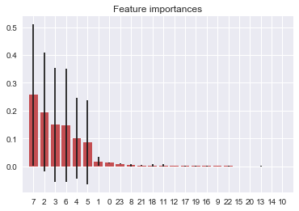

```python
# Get a sense of feature importance
importances = rf_model.feature_importances_
std = np.std([tree.feature_importances_ for tree in rf_model.estimators_],
             axis=0)
indices = np.argsort(importances)[::-1]

# Print the feature ranking
print("Feature ranking:")

for f in range(X.shape[1]):
    print("%d. feature %d (%f)" % (f + 1, indices[f], importances[indices[f]]))

# Plot the feature importances of the forest
plt.figure()
plt.title("Feature importances")
plt.bar(range(X.shape[1]), importances[indices],
       color="r", yerr=std[indices], align="center")
plt.xticks(range(X.shape[1]), indices)
plt.xlim([-1, X.shape[1]])
plt.show()
```

# RNNs

Implement the RNN models using 2 different approaches.

```python
# Read in the data
full_df = pd.read_csv("df_weather_scaled_encoded.csv")
```

```python
# Filter by the city of interest
current_city = "Charlotte"

full_df = full_df[full_df["city"] == current_city]

# Store max and min temperatures for denormalization
min_dataset = 0.515
max_dataset = 99.95
```

```python
# Extract
years = np.array([y[0:4] for y in full_df.datetime])

# Split into train, test, validation
train = full_df[years < '2016']
valid = full_df[years == '2016']
test = full_df[years > '2016']

if(train.shape[0] + valid.shape[0] + test.shape[0] != years.shape[0]):
    raise Exception("Partition did not work")

# Drop the city and timestamp for all three
train.drop(["city", "datetime"], inplace=True, axis=1)
valid.drop(["city", "datetime"], inplace=True, axis=1)
test.drop(["city", "datetime"], inplace=True, axis=1)
```

```python
# Wrapper for data object
# Modified from Mohammad Al Boni

class DataSet(object):
    def __init__(self, x, y, shuffle=True):
        self._num_examples = len(x)
        self._x = x
        self._y = y
        self._epochs_done = 0
        self._index_in_epoch = 0
        if shuffle:
            np.random.seed(123456)
            # Shuffle the data
            perm = np.arange(self._num_examples)
            np.random.shuffle(perm)
            self._x = [self._x[i] for i in perm]
            self._y = [self._y[i] for i in perm]
        random.seed(123456)
    @property
    def features(self):
        return self._x
    @property
    def response(self):
        return self._y
    @property
    def num_examples(self):
        return self._num_examples
    @property
    def epochs_done(self):
        return self._epochs_done

    def reset_batch_index(self):
        self._index_in_epoch = 0

    def next_batch(self, batch_size):
        """Return the next `batch_size` examples from this data set."""
        start = self._index_in_epoch
        self._index_in_epoch += batch_size
        done = False

        if self._index_in_epoch > self._num_examples:
            # After each epoch we update this
            self._epochs_done += 1
            # Shuffle the data
            perm = np.arange(self._num_examples)
            np.random.shuffle(perm)
            self._x = self._x
            self._y = self._y
            start = 0
            self._index_in_epoch = batch_size
            done = True
            assert batch_size <= self._num_examples
        end = self._index_in_epoch

        return self._x[start:end], self._y[start:end], done
```

## Create observations using a sliding sequence window

```python
# Wrapper function to perform the entire creation of observations given the subset
# data. Can specify sequence_size, lookahead, response (temp means 'temperature'),
# and whether you want a greedy baseline.
def create_observations(train, test, valid, seq_size = 24, lookahead = 1, temp = True, baseline=False):

    train_x = []
    train_y = []
    # If we are doing the temperature variable, extract that feature
    if temp:
        for i in range(train.shape[0] - seq_len - lookahead + 1):
            # Slide over input, storing each "sequence size" window
            train_x.append([x for x in train.iloc[i:i+seq_len, :].values])
            train_y.append([y for y in train.iloc[i+lookahead:i+seq_len+lookahead, 0]])
    # Otherwise, extract out the weather type
    else:
        for i in range(train.shape[0] - seq_len  - lookahead + 1):
            train_x.append([x for x in train.iloc[i:i+seq_len, :].values])
            train_y.append([y for y in train.iloc[i+lookahead:i+seq_len+lookahead, -7:].values])

    # Convert to a Dataset object
    train_data = DataSet(train_x, train_y)

    # Repeat the above process on the validation set
    valid_x = []
    valid_y = []

    # If we are doing the temperature variable, extract that feature
    if temp:
        for i in range(valid.shape[0] - seq_len - lookahead + 1):
            # Slide over input, storing each "sequence size" window
            valid_x.append([x for x in valid.iloc[i:i+seq_len, :].values])
            valid_y.append([y for y in valid.iloc[i+lookahead:i+seq_len+lookahead, 0]])
    # Otherwise, extract out the weather type
    else:
        for i in range(valid.shape[0] - seq_len - lookahead + 1):
            valid_x.append([x for x in valid.iloc[i:i+seq_len, :].values])
            valid_y.append([y for y in valid.iloc[i+lookahead:i+seq_len+lookahead, -7:].values])

    valid_data = DataSet(valid_x, valid_y)


    # Repeat for test except also track the baseline prediction error
    test_x = []
    test_y = []
    test_baseline_err = []

    if temp:
        for i in range(test.shape[0] - seq_len - lookahead + 1):
            test_x.append([x for x in test.iloc[i:i+seq_len, :].values])
            test_y.append([y for y in test.iloc[i+lookahead:i+seq_len+lookahead, 0]])

            # Get the baseline prediction error by taking the MSE between the current hour and the
            # temperature of the next hour. This is the trivial case where our prediction for temp
            # is just the current temp
            if baseline:
                test_baseline_err.append((np.mean(test.iloc[i:i+seq_len, 0]*(max_dataset-min_dataset)+min_dataset) -
                                      (test.iloc[i+seq_len + lookahead - 1, 0]*(max_dataset-min_dataset)+min_dataset)) ** 2)

        if baseline:
            print("Baseline error of: " + str(np.mean(test_baseline_err)))
        # Test baseline for seq 1: 29.66645546285467
        # Test baseline for seq 2: 34.86351968736361
        # Test baseline error for seq 24: 34.01255035338878
        # Test baseline error for seq 72: 42.73780841606058
    else:

        for i in range(test.shape[0] - seq_len - lookahead + 1):
            test_x.append([x for x in test.iloc[i:i+seq_len, :].values])
            test_y.append([y for y in test.iloc[i+lookahead:i+seq_len+lookahead, -7:].values])


            if baseline:
                # Compare current weather type with the most common weather type over a period

                # Variable to hold most frequent weather type
                x_obs = np.array([sum(x) for x in zip(*test.iloc[i:i+seq_len, -7:].values)])

                # Append equality of current prediction and true value to error list
                test_baseline_err.append(np.argmax(x_obs) == np.argmax(test.iloc[i + seq_len + lookahead - 1, -7:].values))


        if baseline:
            print("Baseline error of: " + str(np.mean(test_baseline_err)))

        # Test baseline error of 0.595

    test_data = DataSet(test_x, test_y, shuffle=False)

    return train_data, valid_data, test_data
```

## Model 1: Temperature Prediction

Try to predict the temperature 4 hours into the future with a number of different sequence lengths.

```python
# Define the RNN model
# Modified from Mohammad Al Boni
def build_and_save_d(modelDir,train,valid,cell,cellType,input_dim=1,hidden_dim=100,
                          seq_size = 12,max_itr=200,keep_prob=0.5, batch_size=32, num_epochs=10, log=500,
                            early_stopping=3, learning_rate=0.01):
    tf.reset_default_graph()
    graph = tf.Graph()
    with graph.as_default():
        # input place holders
        # input Shape: [# training examples, sequence length, # features]
        x = tf.placeholder(tf.float32,[None,seq_size,input_dim],name="x_in")
        # label Shape: [# training examples, sequence length]
        y = tf.placeholder(tf.float32,[None,seq_size],name="y_in")
        dropout = tf.placeholder(tf.float32,name="dropout_in")

        # Function to wrap each cell with dropout
        def wrap_cell(cell, keep_prob):
            drop = tf.nn.rnn_cell.DropoutWrapper(cell, output_keep_prob=keep_prob)
            return drop

        cells = tf.nn.rnn_cell.MultiRNNCell(
                 [wrap_cell(cell,keep_prob) for cell in cell]
         )

        # cell = tf.nn.rnn_cell.DropoutWrapper(cell)
        # RNN output Shape: [# training examples, sequence length, # hidden]
        outputs, _ = tf.nn.dynamic_rnn(cells,x,dtype=tf.float32)


        # weights for output dense layer (i.e., after RNN)
        # W shape: [# hidden, 1]
        W_out = tf.Variable(tf.random_normal([hidden_dim,1]),name="w_out")
        # b shape: [1]
        b_out = tf.Variable(tf.random_normal([1]),name="b_out")

        # output dense layer:
        num_examples = tf.shape(x)[0]
        # convert W from [# hidden, 1] to [# training examples, # hidden, 1]
        # step 1: add a new dimension at index 0 using tf.expand_dims
        w_exp= tf.expand_dims(W_out,0)
        # step 2: duplicate W for 'num_examples' times using tf.tile
        W_repeated = tf.tile(w_exp,[num_examples,1,1])

        # Dense Layer calculation:
        # [# training examples, sequence length, # hidden] *
        # [# training examples, # hidden, 1] = [# training examples, sequence length]

        y_pred = tf.matmul(outputs,W_repeated)+b_out
        # Actually, y_pred: [# training examples, sequence length, 1]
        # Remove last dimension using tf.squeeze
        y_pred = tf.squeeze(y_pred,name="y_pred")

        # Cost & Training Step
        cost = tf.reduce_mean(tf.square(y_pred-y))
        train_op = tf.train.AdamOptimizer(learning_rate=learning_rate).minimize(cost)
        saver=tf.train.Saver()



        # Run Session
    with tf.Session(graph=graph) as sess:
        # initialize variables
        sess.run(tf.global_variables_initializer())
        # Run for 1000 iterations (1000 is arbitrary, need a validation set to tune!)
        start=timeit.default_timer()
        epoch_counter = 0 # Keep track of our epochs
        i = 0 # Keep track of our iterations
        min_validation_err = sys.float_info.max # Start min error at biggest number
        min_validation_itr = 0 # Keep track of the smallest validation error we have seen so far
        early_stopping_counter = 0 # Counter to see if we have acheived early stopping
        min_denorm_err = None
        print('Training %s ...'%cellType)
        while True: # If we train more, would we overfit? Try 10000
            i += 1 # Increment counter
            trainX, trainY, done = train.next_batch(batch_size) # Get train batch
            # See if we are done with our epochs
            if done:
                epoch_counter += 1
                print("Done with epoch " + str(epoch_counter))
                if epoch_counter >= num_epochs:
                    break

            # Pass the data through the network
            _, train_err = sess.run([train_op,cost],feed_dict={x:trainX,y:trainY,dropout:keep_prob})
            if i==0:
                print('  step, train err= %6d: %8.5f' % (0,train_err))
            # Every 'log' steps, print out train error and validation error.
            # Update early stopping at these points
            elif  (i+1) % log == 0:
                print('  step, train err= %6d: %8.5f' % (i+1,train_err))

                # Get validation error on the full validation set
                valid_err, predicted_vals_rnn = sess.run([cost, y_pred],feed_dict={x:valid.features,y:valid.response,dropout:1})

                # Compute denormalized MSE
                # step 1: denormalize data
                # If seq_len greater than 1, get only the last element
                if seq_size > 1:
                    predicted_vals_rnn = predicted_vals_rnn[:,seq_size-1]
                predicted_vals_dnorm_rnn=predicted_vals_rnn*(max_dataset-min_dataset)+min_dataset
                # step 2: get ground-truth, also must be denormalized
                actual_test= np.array([x[-1] for x in valid.response])*(max_dataset-min_dataset)+min_dataset
                # step 3: compute MSE
                mse_rnn= ((predicted_vals_dnorm_rnn - actual_test) ** 2).mean()
                print('  step, validation err= %6d: %8.5f' % (i+1,valid_err))
                print('  step, denorm validation err= %6d: %8.5f' % (i+1,mse_rnn))

                # Check early stopping
                early_stopping_counter += 1
                # If we have smaller validation error, reset counter and
                # assign new smallest validation error. Also store the
                # current iterqtion as the iteration where the current min is
                if valid_err < min_validation_err:
                    min_validation_err = valid_err
                    min_validation_itr = i + 1
                    early_stopping_counter = 0
                    min_denorm_err = mse_rnn

                    # Store the current best model
                    modelPath= saver.save(sess,"%s/model_%s"%(modelDir,cellType),global_step=i+1)
                    print("model saved:%s"%modelPath)

                # Break if we achieve early stopping
                if early_stopping_counter > early_stopping:
                    break

        end=timeit.default_timer()
        print("Training time : %10.5f"%(end-start))

        # Log the results to a file
        with open(modelDir + "/results.txt", 'a+') as file:
            file.write(cellType + "\n")
            file.write("Time taken: " + str(end - start) + "\n")
            file.write("Itr stopped: " + str(min_validation_itr) + "\n")
            file.write("Min validation error: " + str(min_validation_err) + "\n")
            file.write("Denormalized validation error: " + str(min_denorm_err) + "\n\n")


    return min_validation_itr, min_validation_err

# Load back in a model and create predicted values
def load_and_predict(test,modelDir,cellType,itr,seq_size):
    # Restore the session
    with tf.Session() as sess:
        print ("Load model:%s-%s"%(modelDir,itr))
        saver = tf.train.import_meta_graph("%s/model_%s-%s.meta"%(modelDir,cellType,itr))
        saver.restore(sess,tf.train.latest_checkpoint("%s"%modelDir))
        graph = tf.get_default_graph()
        # print all nodes in saved graph
        #print([n.name for n in tf.get_default_graph().as_graph_def().node])
        # get tensors by name to use in prediction
        x = graph.get_tensor_by_name("x_in:0")
        dropout= graph.get_tensor_by_name("dropout_in:0")
        y_pred = graph.get_tensor_by_name("y_pred:0")

        # Feed entire test set to get predictions
        predicted_vals_all= sess.run(y_pred, feed_dict={ x: test.features, dropout:1})
        # Get last item in each predicted sequence:
        predicted_vals = predicted_vals_all[:,seq_size-1]
    return predicted_vals
```

```python
# Function to predict and plot the test set
def predict(test_data, modelDir, cellType, end_itr, seq_len):
    # Load and predict
    predicted_vals_rnn=load_and_predict(test_data,modelDir,cellType,end_itr,seq_len)

    # Compute MSE
    # step 1: denormalize data
    predicted_vals_dnorm_rnn=predicted_vals_rnn*(max_dataset-min_dataset)+min_dataset
    # step 2: get ground-truth, also must be denormalized
    actual_test= np.array([x[-1] for x in test_data.response])*(max_dataset-min_dataset)+min_dataset
    # step 3: compute MSE
    mse_rnn= ((predicted_vals_dnorm_rnn - actual_test) ** 2).mean()

    print("RNN MSE = %10.5f"%mse_rnn)

    pred_len=len(predicted_vals_dnorm_rnn)
    train_len=len(test_data.features)

    pred_avg = []
    actual_avg = []
    # Compute the moving average of each set for visual purposes
    moving_length = 24
    for i in range(len(actual_test) - moving_length):
        pred_avg.append(np.mean(predicted_vals_dnorm_rnn[i:i+moving_length]))
        actual_avg.append(np.mean(actual_test[i:i+moving_length]))

    # Plot the results
    plt.figure()
    plt.plot(list(range(len(actual_test))), actual_test, label="Actual", color='r', alpha=1)
    plt.plot(list(range(len(actual_test))), predicted_vals_dnorm_rnn, color='b',  label=cellType, alpha=0.6)
#    plt.plot(list(range(int(moving_length/2), len(actual_test)-int(moving_length/2))), pred_avg, color='y', label="{0} MA".format(cellType), alpha=0.7)
#    plt.plot(list(range(int(moving_length/2), len(actual_test)-int(moving_length/2))), actual_avg, color='b', label="Actual MA", alpha=0.7)
    plt.title("Cell Type: " + cellType + ", Sequence Length " + str(seq_len))
    plt.legend()
    plt.savefig("{0}{1}.png".format(cellType, seq_len))
```

```python
# Define size of sequence
seq_len = 2

# Create the data
train_data,valid_data,test_data = create_observations(train, valid, test, seq_size=seq_len, temp=True, lookahead=4, baseline=False)
```

### Crude grid search results

```python
"""
# Perform a crude grid search
from itertools import product
# Define learning rates, dropout
params = [[0.1, 0.01, 0.001], [0.25, 0.5, 0.75]]
# Iterate over all combinations and test model
# with those parameters, storing the min
min_param_val = sys.float_info.max
min_param_elems = None
for elem in product(*params):
    # Unpack the values
    learning_rate, keep_prob = elem
    RNNcell = [rnn.BasicLSTMCell(hidden_dim) for _ in range(n_layers)]
    cellType = "LSTM"

    # Build models and save model
    end_itr, min_err = build_and_save_d(modelDir=modelDir,
                     train=train_data,
                     valid=valid_data,
                     cell=RNNcell,
                     cellType=cellType,
                     input_dim=input_dim,=
                     hidden_dim=hidden_dim,
                     seq_size=seq_len,
                     keep_prob=keep_prob,
                     batch_size=batch_size,
                     num_epochs=num_epochs,
                     log=log,
                     early_stopping=early_stopping,
                     learning_rate=learning_rate)
    # See if we have a new low error
    if min_err < min_param_val:
        min_param_val = min_err
        min_param_elems = elem
    print("Min validation error " + str(min_err) + " for elems " + str(elem))

print("Global validation error " + str(min_param_val) + " for elems " + str(min_param_elems))
"""

# Grid search on learning rate and dropout

# RNN

#Min validation error 0.015986204 for elems (0.1, 0.25)
#Min validation error 0.015794938 for elems (0.1, 0.5)
#Min validation error 0.015503254 for elems (0.1, 0.75)
#Min validation error 0.012949656 for elems (0.01, 0.25)
#Min validation error 0.006430081 for elems (0.01, 0.5)
#Min validation error 0.0046402193 for elems (0.01, 0.75)
#Min validation error 0.029264465 for elems (0.001, 0.25)
#Min validation error 0.012221504 for elems (0.001, 0.5)
#Min validation error 0.008622245 for elems (0.001, 0.75)
#Global validation error 0.0046402193 for elems (0.01, 0.75)

# GRU

#Min validation error 0.0111637125 for elems (0.1, 0.25)
#Min validation error 0.012049832 for elems (0.1, 0.5)
#Min validation error 0.017291395 for elems (0.1, 0.75)
#Min validation error 0.0037756523 for elems (0.01, 0.25)
#Min validation error 0.002122913 for elems (0.01, 0.5)
#Min validation error 0.0032095483 for elems (0.01, 0.75)
#Min validation error 0.00797302 for elems (0.001, 0.25)
#Min validation error 0.008556419 for elems (0.001, 0.5)
#Min validation error 0.0030354045 for elems (0.001, 0.75)
#Global validation error 0.002122913 for elems (0.01, 0.5)

# LSTM

#Min validation error 0.0039516427 for elems (0.1, 0.25)
#Min validation error 0.016133798 for elems (0.1, 0.5)
#Min validation error 0.008657359 for elems (0.1, 0.75)
#Min validation error 0.0010539122 for elems (0.01, 0.25)
#Min validation error 0.0023624634 for elems (0.01, 0.5)
#Min validation error 0.002788953 for elems (0.01, 0.75)
#Min validation error 0.002642741 for elems (0.001, 0.25)
#Min validation error 0.0013699796 for elems (0.001, 0.5)
#Min validation error 0.0020976907 for elems (0.001, 0.75)
#Global validation error 0.0010539122 for elems (0.01, 0.25)

# Seems pretty close overall, choose 0.01 and dropout 0.5
```

### Run the model

```python
input_dim=19 # dim > 1 for multivariate time series
hidden_dim=100 # number of hiddent units h
keep_prob=0.5
modelDir='modelDir'
log=500 # How often we validate
batch_size=16
num_epochs=15 # MAXIMUM number of epochs (i.e if early stopping is never achieved)
early_stopping = 5 # Number of validation steps without improvement until we stop
learning_rate = 0.01
n_layers = 2

# NEED TO MAKE DIFFERENT COPIES OF THE CELL TO AVOID SELF-REFENTIAL ERRORS
# RNNcell = [rnn.BasicRNNCell(hidden_dim) for _ in range(1)]
# cellType = "RNN"

RNNcell = [rnn.BasicRNNCell(hidden_dim) for _ in range(n_layers)]
cellType = "RNN"

# Build models and save model
end_itr, min_err = build_and_save_d(modelDir=modelDir,
                 train=train_data,
                 valid=valid_data,
                 cell=RNNcell,
                 cellType=cellType,
                 input_dim=input_dim,
                 hidden_dim=hidden_dim,
                 seq_size=seq_len,
                 keep_prob=keep_prob,
                 batch_size=batch_size,
                 num_epochs=num_epochs,
                 log=log,
                 early_stopping=early_stopping,
                 learning_rate=learning_rate)

predict(test_data, modelDir, cellType, end_itr, seq_len)

RNNcell = [rnn.GRUCell(hidden_dim) for _ in range(n_layers)]
cellType = "GRU"

# Build models and save model
end_itr, min_err = build_and_save_d(modelDir=modelDir,
                 train=train_data,
                 valid=valid_data,
                 cell=RNNcell,
                 cellType=cellType,
                 input_dim=input_dim,
                 hidden_dim=hidden_dim,
                 seq_size=seq_len,
                 keep_prob=keep_prob,
                 batch_size=batch_size,
                 num_epochs=num_epochs,
                 log=log,
                 early_stopping=early_stopping,
                 learning_rate=learning_rate)

predict(test_data, modelDir, cellType, end_itr, seq_len)

RNNcell = [rnn.BasicLSTMCell(hidden_dim) for _ in range(n_layers)]
cellType = "LSTM"

# Build models and save model
end_itr, min_err = build_and_save_d(modelDir=modelDir,
                 train=train_data,
                 valid=valid_data,
                 cell=RNNcell,
                 cellType=cellType,
                 input_dim=input_dim,
                 hidden_dim=hidden_dim,
                 seq_size=seq_len,
                 keep_prob=keep_prob,
                 batch_size=batch_size,
                 num_epochs=num_epochs,
                 log=log,
                 early_stopping=early_stopping,
                 learning_rate=learning_rate)


predict(test_data, modelDir, cellType, end_itr, seq_len)
```

### Results

Seq Len: 2

RNN

Time taken: 25.785779288000413  
Itr stopped: 8500  
Min validation error: 0.0031018716  
Denormalized validation error: 31.769728957977332

GRU

Time taken: 41.09399954499895  
Itr stopped: 8500  
Min validation error: 0.0026672964  
Denormalized validation error: 26.344573167959652

LSTM

Time taken: 69.01221254200027  
Itr stopped: 17500  
Min validation error: 0.002471932  
Denormalized validation error: 21.351730504118457

Seq Len: 24

RNN

Time taken: 246.51083700100025  
Itr stopped: 17500  
Min validation error: 0.001986726  
Denormalized validation error: 18.504949918661264

GRU

Time taken: 487.5709146240006  
Itr stopped: 18000  
Min validation error: 0.001339163  
Denormalized validation error: 10.45840469361726

LSTM

Time taken: 432.73047026600034  
Itr stopped: 18500  
Min validation error: 0.0013122336  
Denormalized validation error: 9.057215740626543

Seq Len: 72

RNN

Time taken: 723.7870445440003  
Itr stopped: 19000  
Min validation error: 0.0012962609  
Denormalized validation error: 10.682260107741136

GRU

Time taken: 1246.9418031219993  
Itr stopped: 15500  
Min validation error: 0.0010465818  
Denormalized validation error: 8.61281120826994

LSTM

Time taken: 1108.5033689619995  
Itr stopped: 13500  
Min validation error: 0.0009968199  
Denormalized validation error: 7.759870622882436

Seq Len: 96

RNN

Time taken: 907.123842844001  
Itr stopped: 15000  
Min validation error: 0.0010954492  
Denormalized validation error: 8.885591086046022

GRU

Time taken: 1511.5696144740032  
Itr stopped: 13000  
Min validation error: 0.001024862  
Denormalized validation error: 8.57339568785667

LSTM

Time taken: 1151.6507261309998  
Itr stopped: 11000  
Min validation error: 0.00092091894  
Denormalized validation error: 7.558516922265615

## Model 2: Weather Type Prediction

This time change to try to predict the weather type.

```python
# Define the second kind of RNN
# Modified from Mohammad Al Boni
def build_and_save_d2(modelDir,train,valid,cell,cellType,input_dim=1,hidden_dim=100,
                          seq_size = 12,max_itr=200,keep_prob=0.5, batch_size=32, num_epochs=10,log=500,save=1000):
    tf.reset_default_graph()
    graph = tf.Graph()
    with graph.as_default():
        # input place holders, note the change in dimensions in y, which
        # now has 7 dimensions

        # input Shape: [# training examples, sequence length, # features]
        x = tf.placeholder(tf.float32,[None,seq_size,input_dim],name="x_in")
        # label Shape: [# training examples, sequence length, # classes]
        y = tf.placeholder(tf.float32,[None,seq_size,7],name="y_in")
        dropout = tf.placeholder(tf.float32,name="dropout_in")

        # Function to wrap each cell with dropout
        def wrap_cell(cell, keep_prob):
            drop = tf.nn.rnn_cell.DropoutWrapper(cell, output_keep_prob=keep_prob)
            return drop

        cells = tf.nn.rnn_cell.MultiRNNCell(
                 [wrap_cell(cell,keep_prob) for cell in cell]
         )

        # RNN output Shape: [# training examples, sequence length, # hidden]
        outputs, _ = tf.nn.dynamic_rnn(cells,x,dtype=tf.float32)


        # weights for output dense layer (i.e., after RNN)
        # W shape: [# hidden, 7]
        W_out = tf.Variable(tf.random_normal([hidden_dim,7]),name="w_out")
        # b shape: [7]
        b_out = tf.Variable(tf.random_normal([7]),name="b_out")

        # output dense layer:
        num_examples = tf.shape(x)[0]
        # convert W from [# hidden, 7] to [# training examples, # hidden, 7]
        # step 1: add a new dimension at index 0 using tf.expand_dims
        w_exp= tf.expand_dims(W_out,0)
        # step 2: duplicate W for 'num_examples' times using tf.tile
        W_repeated = tf.tile(w_exp,[num_examples,1,1])

        # Dense Layer calculation:
        # [# training examples, sequence length, # hidden] *
        # [# training examples, # hidden, 7] = [# training examples, sequence length, 7]

        y_pred = tf.matmul(outputs,W_repeated) + b_out
        y_pred = tf.add(y_pred, b_out, name="y_out")

        # Cost & Training Step
        # Minimize error with softmax cross entropy
        cost = tf.reduce_mean(tf.nn.softmax_cross_entropy_with_logitsv2(logits=y_pred, labels=y))
        train_op = tf.train.AdamOptimizer(learning_rate=0.01).minimize(cost)
        saver=tf.train.Saver()

        # Run Session
        with tf.Session(graph=graph) as sess:
            # initialize variables
            sess.run(tf.global_variables_initializer())
            # Run for 1000 iterations (1000 is arbitrary, need a validation set to tune!)
            start=timeit.default_timer()
            epoch_counter = 0 # Keep track of our epochs
            i = 0 # Keep track of our iterations
            min_validation_err = sys.float_info.max # Start min error at biggest number
            min_validation_itr = 0 # Keep track of the smallest validation error we have seen so far
            early_stopping_counter = 0 # Counter to see if we have acheived early stopping
            min_accuracy=None
            print('Training %s ...'%cellType)
            while True: # If we train more, would we overfit? Try 10000
                i += 1 # Increment counter
                trainX, trainY, done = train.next_batch(batch_size) # Get train batch
                # See if we are done with our epochs
                if done:
                    epoch_counter += 1
                    print("Done with epoch " + str(epoch_counter))
                    if epoch_counter >= num_epochs:
                        break

                # Pass the data through the network
                _, train_err = sess.run([train_op,cost],feed_dict={x:trainX,y:trainY,dropout:keep_prob})
                if i==0:
                    print('  step, train err= %6d: %8.5f' % (0,train_err))
                # Every 'log' steps, print out train error and validation error.
                # Update early stopping at these points
                elif  (i+1) % log == 0:
                    print('  step, train err= %6d: %8.5f' % (i+1,train_err))

                    # Get validation error on the full validation set
                    valid_err, pred = sess.run([cost, y_pred],feed_dict={x:valid.features,y:valid.response,dropout:1})
                    print('  step, validation err= %6d: %8.5f' % (i+1,valid_err))
                    pred = pred[:,seq_size-1]
                    actual_valid = np.array([x[-1] for x in valid.response])
                    # Look at the distribution of the output
                    amax = np.argmax(pred, axis=1)
                    accuracy = sum(np.argmax(actual_valid, axis=1) == np.argmax(pred, axis=1))/len(pred)
                    print("Accuracy of: " + str(accuracy))

                    # Check early stopping
                    early_stopping_counter += 1
                    # If we have smaller validation error, reset counter and
                    # assign new smallest validation error. Also store the
                    # current iterqtion as the iteration where the current min is
                    if valid_err < min_validation_err:
                        min_validation_err = valid_err
                        min_validation_itr = i + 1
                        early_stopping_counter = 0
                        min_accuracy = accuracy
                        # Store the current best model
                        modelPath= saver.save(sess,"%s/model_%s"%(modelDir,cellType),global_step=i+1)
                        print("model saved:%s"%modelPath)

                    # Break if we achieve early stopping
                    if early_stopping_counter > early_stopping:
                        break

            end=timeit.default_timer()
            print("Training time : %10.5f"%(end-start))

            # Log the results to a file
            with open(modelDir + "/results.txt", 'a+') as file:
                file.write(cellType + "\n")
                file.write("Time taken: " + str(end - start) + "\n")
                file.write("Itr stopped: " + str(min_validation_itr) + "\n")
                file.write("Min validation error: " + str(min_validation_err) + "\n")
                file.write("Min validation accuracy: " + str(min_accuracy) + "\n\n")
        # Return the min validation error and the iteration in which it occured
        return min_validation_itr, min_validation_err

# Load back in the model
def load_and_predict2(test,modelDir,cellType,itr,seq_size):
    with tf.Session() as sess:
        print ("Load model:%s-%s"%(modelDir,itr))
        saver = tf.train.import_meta_graph("%s/model_%s-%s.meta"%(modelDir,cellType,itr))
        saver.restore(sess,tf.train.latest_checkpoint("%s"%modelDir))
        graph = tf.get_default_graph()

        x = graph.get_tensor_by_name("x_in:0")
        dropout= graph.get_tensor_by_name("dropout_in:0")
        y_pred = graph.get_tensor_by_name("y_out:0")

        predicted_vals_all= sess.run(y_pred, feed_dict={ x: test.features, dropout:1})
        # Get last item in each predicted sequence:
        predicted_vals = predicted_vals_all[:,seq_size-1]
    return predicted_vals
```

```python
# Take in test set and print accuracy and F1-score
def predict_type(test,modelDir,cellType,itr,seq_size):

    # Load and predict
    predicted_vals_rnn=load_and_predict2(test_data2,modelDir,cellType,end_itr,seq_len)

    # Compute accuracy
    # step 2: get ground-truth
    actual_test= np.array([x[-1] for x in test_data2.response])

    # Get raw accuracy
    accuracy = sum(np.argmax(actual_test, axis=1) == np.argmax(predicted_vals_rnn, axis=1))/len(actual_test)
    print("Accuracy: " + str(accuracy))
    # Calculate f1_score

    # Convert the continuous valued predictions
    # to one hot
    preds = np.zeros([len(actual_test), 7])
    for i in range(len(actual_test)):
        preds[i, np.argmax(predicted_vals_rnn[i])] = 1
    # Use the weighted version for more accuracy in the multiclass setting
    print("F1 score: " + str(f1_score(actual_test, preds, average="weighted")))
```

### Read in observations and run the model

```python
# Define size of sequence, 1 day for now
seq_len = 2

train_data2,valid_data2,test_data2 = create_observations(train, valid, test, seq_size=seq_len, temp=False, lookahead=4, baseline=True)
```

```python
input_dim=19 # dim > 1 for multivariate time series
hidden_dim=100 # number of hiddent units h
keep_prob=0.75
modelDir='modelDir2' # Make sure to use a different model dir
log=500 # How often we validate
batch_size=16
num_epochs=15 # MAXIMUM number of epochs (i.e if early stopping is never achieved)
early_stopping=10 # Number of validation steps without improvement until we stop
num_layers = 2

# Different RNN Cell Types
# NEED TO MAKE DIFFERENT COPIES OF THE CELL TO AVOID SELF-REFENTIAL ERRORS
RNNcell = [rnn.BasicRNNCell(hidden_dim) for _ in range(num_layers)]
cellType = "RNN"

# Build models and save model
end_itr, min_err = build_and_save_d2(modelDir=modelDir,
                 train=train_data2,
                 valid=valid_data2,
                 cell=RNNcell,
                 cellType=cellType,
                 input_dim=input_dim,
                 hidden_dim=hidden_dim,
                 seq_size=seq_len,
                 keep_prob=keep_prob,
                 batch_size=batch_size,
                 num_epochs=num_epochs,
                 log=log)

predict_type(test_data2, modelDir, cellType, end_itr, seq_len)

RNNcell = [rnn.GRUCell(hidden_dim) for _ in range(num_layers)]
cellType = "GRU"



# Build models and save model
end_itr, min_err = build_and_save_d2(modelDir=modelDir,
                 train=train_data2,
                 valid=valid_data2,
                 cell=RNNcell,
                 cellType=cellType,
                 input_dim=input_dim,
                 hidden_dim=hidden_dim,
                 seq_size=seq_len,
                 keep_prob=keep_prob,
                 batch_size=batch_size,
                 num_epochs=num_epochs,
                 log=log)

predict_type(test_data2, modelDir, cellType, end_itr, seq_len)

RNNcell = [rnn.BasicLSTMCell(hidden_dim) for _ in range(num_layers)]
cellType = "LSTM"


# Build models and save model
end_itr, min_err = build_and_save_d2(modelDir=modelDir,
                 train=train_data2,
                 valid=valid_data2,
                 cell=RNNcell,
                 cellType=cellType,
                 input_dim=input_dim,
                 hidden_dim=hidden_dim,
                 seq_size=seq_len,
                 keep_prob=keep_prob,
                 batch_size=batch_size,
                 num_epochs=num_epochs,
                 log=log)

predict_type(test_data2, modelDir, cellType, end_itr, seq_len)
```

### Results

Seq Len: 2

RNN

Training time : 26.06421  
Load model:modelDir2-3000  
INFO:tensorflow:Restoring parameters from modelDir2/model_RNN-3000  
Accuracy: 0.5818430345141816  
F1 score: 0.5751496500102374

GRU

Training time : 68.72410  
Load model:modelDir2-9500  
INFO:tensorflow:Restoring parameters from modelDir2/model_GRU-9500  
Accuracy: 0.5961954664540381  
F1 score: 0.5916327029106627

LSTM

Training time : 71.13695  
Load model:modelDir2-11500  
INFO:tensorflow:Restoring parameters from modelDir2/model_LSTM-11500  
Accuracy: 0.6037134069939629  
F1 score: 0.5971185305032227

Seq Len: 24

RNN

Training time : 78.50333  
Load model:modelDir2-3000  
INFO:tensorflow:Restoring parameters from modelDir2/model_RNN-3000  
Accuracy: 0.5922119447299303  
F1 score: 0.5910033794373887

GRU

Training time : 88.32919  
Load model:modelDir2-1000  
INFO:tensorflow:Restoring parameters from modelDir2/model_GRU-1000  
Accuracy: 0.5928971108827223  
F1 score: 0.5792721833038622

LSTM

Training time : 90.14142  
Load model:modelDir2-1500  
INFO:tensorflow:Restoring parameters from modelDir2/model_LSTM-1500  
Accuracy: 0.6044307411213886  
F1 score: 0.5905284940134202

Seq Len: 72

RNN

Training time : 314.71831  
Load model:modelDir2-3500  
INFO:tensorflow:Restoring parameters from modelDir2/model_RNN-3500  
Accuracy: 0.5838787461246986  
F1 score: 0.5687409812194684

GRU

Training time : 409.06710  
Load model:modelDir2-500  
INFO:tensorflow:Restoring parameters from modelDir2/model_GRU-500  
Accuracy: 0.5920312320587897  
F1 score: 0.5844762323065641

LSTM

Training time : 398.69022  
Load model:modelDir2-1000  
INFO:tensorflow:Restoring parameters from modelDir2/model_LSTM-1000  
Accuracy: 0.5940980594787002  
F1 score: 0.5796382185477683